# Model

### Splines

```r
bs(degree = 1) # linear splines
bs()           # cubic splines
ns()           # natural splines
```

```r
library(splines)
tidy(lm(income ~ ns(education, knots = c(10, 17)), data = heights))
```

```
##                                term   estimate std.error  statistic
## 1                       (Intercept)  47727.349 15732.056  3.0337643
## 2 ns(education, knots = c(10, 17))1   2906.229 11941.163  0.2433791
## 3 ns(education, knots = c(10, 17))2 -46866.563 31604.008 -1.4829310
## 4 ns(education, knots = c(10, 17))3  25841.733  5475.091  4.7198728
##        p.value
## 1 2.489681e-03
## 2 8.077713e-01
## 3 1.384683e-01
## 4 2.764398e-06
```

```r
tidy(lm(income ~ ns(education, df = 4), data = heights))
```

```
##                     term   estimate std.error  statistic      p.value
## 1            (Intercept)  42023.979  14610.18  2.8763496 0.0041251089
## 2 ns(education, df = 4)1  -3574.248  14167.26 -0.2522893 0.8008792877
## 3 ns(education, df = 4)2  12398.073  10519.35  1.1785970 0.2388932503
## 4 ns(education, df = 4)3 -31924.238  30295.35 -1.0537668 0.2922934424
## 5 ns(education, df = 4)4  20221.451   5818.22  3.4755393 0.0005360181
```

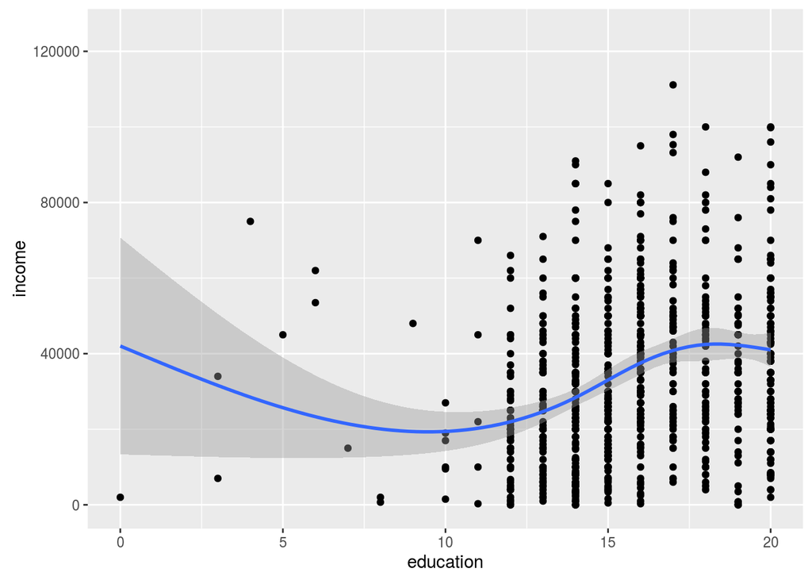

```r
ggplot(data = heights, mapping = aes(x= education, y = income)) +
  geom_point() +
  geom_smooth(method = lm, formula = y ~ ns(x, df = 4)) +
  coord_cartesian(ylim = c(0, 125000))
```

### Additive models

```r
gam(income ~ s(education), data = heights)
```

```
##
## Family: gaussian
## Link function: identity
##
## Formula:
## income ~ s(education)
##
## Estimated degrees of freedom:
## 4.63  total = 5.63
##
## GCV score: 623214907
```

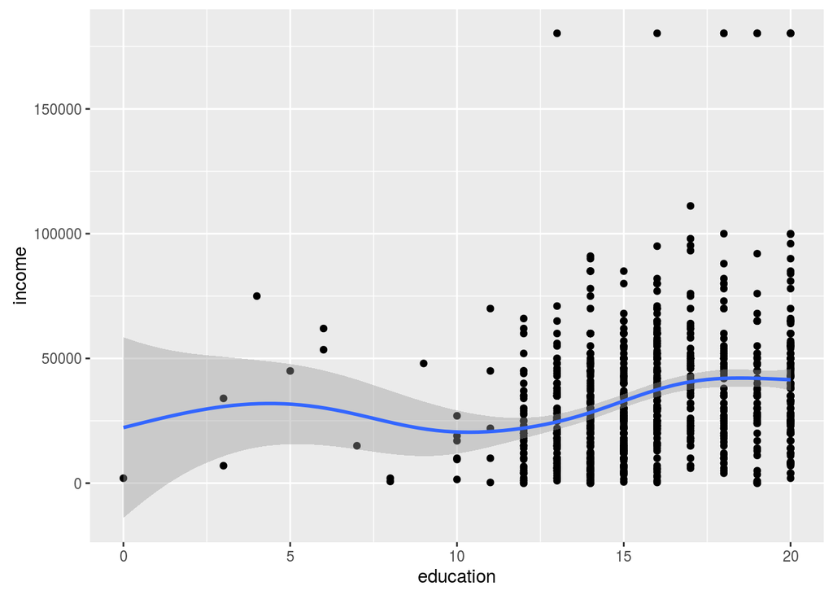

```r
ggplot(data = heights, mapping = aes(x = education, y = income)) +
  geom_point() +
  geom_smooth(method = gam, formula = y ~ s(x))
```

```r
# Linear z
gam(y ~ s(x) + z, data = df)

# Smooth x and smooth z
gam(y ~ s(x) + s(z), data = df)

# Smooth surface of x and z
# (a smooth function that takes both x and z)
gam(y ~ s(x, z), data = df)
```

## Summary

We’ve avoided two things in this chapter that are usually conflated with models: hypothesis testing and predictive analysis.

There are other types of modeling algorithms; each provides a valid description of the data.

Which description will be best? Does the relationship have a known form? Does the data have a known structure? Are you going to attempt hypothesis testing that imposes its own constraints?